# Claw coloration in the fiddler crab *Leptuca uruguayensis* has no correlation with male quality

Graham, Florentino, Smithers, Menezes, de Carvalho & Palaoro

2024-01-08

### Loading data

Setting up the code and loading the data.

```r
color2 = read.csv("D:/Dropbox/Orientados/Mestrado - Jonatas/Paper - Color/claw.colors/data/uca_data_true_reflectance_day2.csv",h=T, sep = ',')

# We removed individual 33 because he was clearly an outlier for the lipid content analysis.
# Since We have no explanation to why this individual was so different, we removed it from the analyses.

color2.t = color2[-33,]

color2.t
```

```
##     ID date.photographed  claw carapace muscle      lipid lipid.percent
## 1  U31          11.23.18 1.027    0.813 0.0024 23.2988166    2.32988166
## 2  U32          11.23.18 0.785    0.714 0.0026  2.0833333    0.20833333
## 3  U33          11.23.18 1.037    0.764 0.0016  8.5526316    0.85526316
## 4  U34          11.23.18 1.062    0.772 0.0034  0.2216312    0.02216312
## 5  U35          11.23.18 1.365    0.918 0.0041 12.9807692    1.29807692
## 6  U36          11.23.18 1.228    0.922 0.0063  9.5000000    0.95000000
## 7  U37          11.23.18 1.494    0.922 0.0061 12.1323529    1.21323529
## 8  U38          11.23.18 1.711    0.931 0.0076  7.1790541    0.71790540
## 9  U39          11.23.18 1.752    1.055 0.0083 13.8771186    1.38771186
## 10 U40          11.23.18 1.893    0.996 0.0107  9.3309859    0.93309859
## 11 U42          11.23.18 1.937    1.065 0.0109 21.4206232    2.14206231
## 12 U44          11.23.18 1.707    0.999 0.0091 26.2668919    2.62668919
## 13 U46          11.23.18 1.355    0.941 0.0040 10.8606557    1.08606557
## 14 U47          11.23.18 1.108    0.743 0.0020 11.9742991    1.19742991
```

[output cut: 57 more lines]

```r
# Since reflectance comes in percentage, I'm dividing by a 100 to give values between 0 and 1. It's easier to interpret

color2.t$red = color2.t$percent.red/100
color2.t$blue = color2.t$percent.blue/100
color2.t$green = color2.t$percent.green/100
```

### Ternary plot

Our first goal is simply to check how much variation we have in reflectance.  
Thus, we’re using a ternary plot to demonstrate how variable reflectance is in this population.

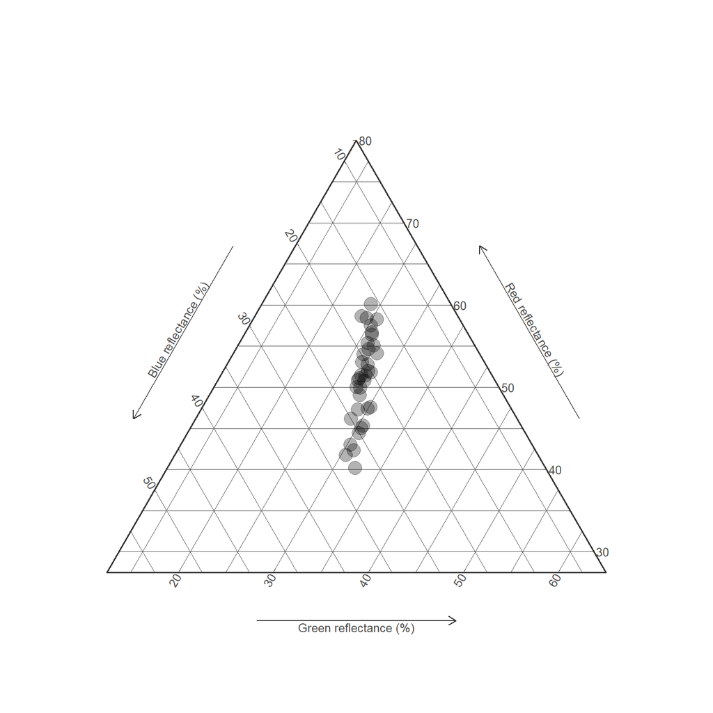

```r
# Now we're just creating a data frame that will make plotting easier.

color.percent = data.frame(color2.t$percent.red,color2.t$percent.green,color2.t$percent.blue)
colnames(color.percent) = c("percent.red","percent.green","percent.blue")

# This is the ternary plot

ggtern(data=color.percent,aes(y=percent.red,z=percent.green,x=percent.blue)) +
  geom_point(size = 5, color = 'black', alpha = .3) +  theme_bw()  +
  theme_hidetitles() +
  theme(panel.grid.major = element_line(colour = "grey30"),
        panel.grid.minor = element_line(colour = 'grey30')) +
  theme_showarrows() + theme_ticksinside() +
  limit_tern(T = .8,
             L = .6,
             R = .65) +
  Tarrowlab("Red reflectance (%)") +
  Larrowlab("Blue reflectance (%)") +
  Rarrowlab("Green reflectance (%)")
```

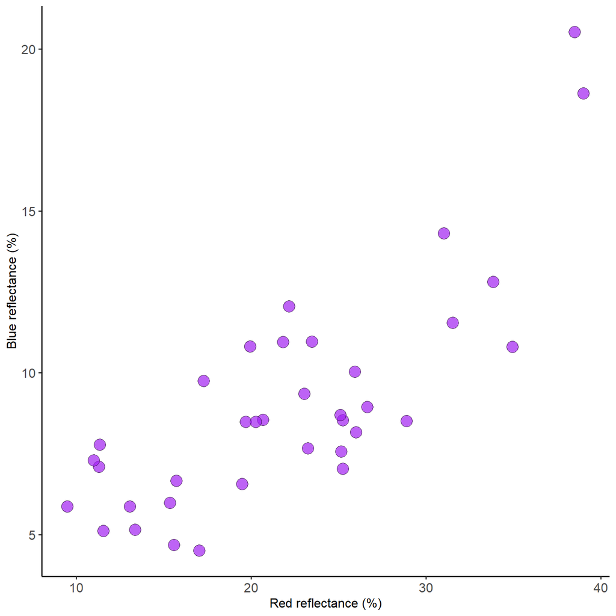

```r
# And this is a plot to see how blue and red reflectance correlate. No analysis, just visual assessment.

ggplot(data = color2, aes(y=percent.blue, x = percent.red)) +
  geom_point(shape = 21, size = 5, colour = 'black', fill = 'purple', alpha = .7) +
  theme_classic() +
  theme(axis.text = element_text(size = 12),
        text = element_text(family = 'sans')) +
  labs( x = "Red reflectance (%)", y = "Blue reflectance (%)")
```

### Spearman correlation - Green + Blue reflectance (a.k.a. Brightness 1)

Now we’re doing the analysis. First, we will run all models with green + blue reflectance. Crabs have a dichromatic vision with peaks on the blue and green spectrum, so we’re analyzing the combination of those spectra. Given that the residuals are poorly behaved for most the correlations, we are using the Spearman’s rank test to test the correlation between brightness 1 and all quality indices.

```r
#Calculating brightness
color2.t$bright2 = color2.t$blue+color2.t$green


### Correlation tests
#Carapace length
car.bright2 = cor.test(x = color2.t$carapace, y = color2.t$bright2, method = 'spearman')
car.bright2
```

```
##
##  Spearman's rank correlation rho
##
## data:  color2.t$carapace and color2.t$bright2
## S = 6397.9, p-value = 0.5524
## alternative hypothesis: true rho is not equal to 0
## sample estimates:
##       rho
## 0.1039288
```

```r
#Claw length
claw.bright2 = cor.test(x = color2.t$claw, y = color2.t$bright2, method = 'spearman')

claw.bright2
```

```
##
##  Spearman's rank correlation rho
##
## data:  color2.t$claw and color2.t$bright2
## S = 7172, p-value = 0.9801
## alternative hypothesis: true rho is not equal to 0
## sample estimates:
##          rho
## -0.004481793
```

```r
#Muscle mass
musc.bright2 = cor.test(x = color2.t$muscle, y = color2.t$bright2, method = 'spearman')
musc.bright2
```

```
##
##  Spearman's rank correlation rho
##
## data:  color2.t$muscle and color2.t$bright2
## S = 7849.2, p-value = 0.5702
## alternative hypothesis: true rho is not equal to 0
## sample estimates:
##         rho
## -0.09932755
```

```r
#Lipid percentage
lipid.bright2 = cor.test(x = color2.t$lipid.percent, y = color2.t$bright2, method = 'spearman')

lipid.bright2
```

```
##
##  Spearman's rank correlation rho
##
## data:  color2.t$lipid.percent and color2.t$bright2
## S = 9084, p-value = 0.1136
## alternative hypothesis: true rho is not equal to 0
## sample estimates:
##        rho
## -0.2722689
```

### Brightness 1 reflectance plots

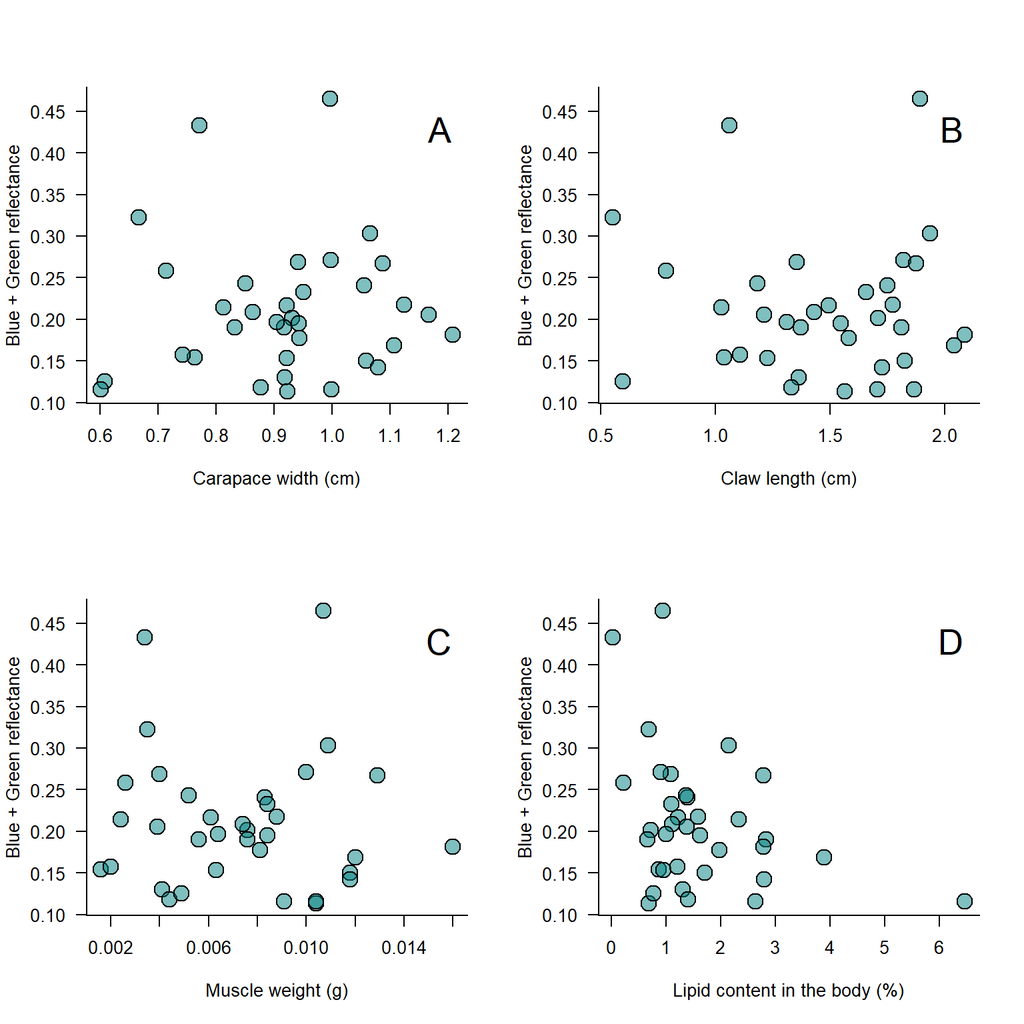

```r
par(mfrow = c(2,2))

plot(bright2 ~ carapace, data = color2.t, bty = 'l', las = 1, xlab = "Carapace width (cm)", ylab = "Blue + Green reflectance",
     pch = 21, cex = 2, bg = alpha('#008080', 0.5))
legend("topright", legend = "A", cex = 2, bty = 'n')

plot(bright2 ~ claw, data = color2.t, bty = 'l', las = 1, xlab = "Claw length (cm)", ylab = "Blue + Green reflectance",
     pch = 21, cex = 2, bg = alpha('#008080', 0.5))

legend("topright", legend = "B", cex = 2, bty = 'n')


plot(bright2 ~ muscle, data = color2.t, bty = 'l', las = 1,
     xlab = "Muscle weight (g)", ylab = "Blue + Green reflectance",
     pch = 21, cex = 2, bg = alpha('#008080', 0.5))

legend("topright", legend = "C", cex = 2, bty = 'n')


plot(x = color2.t$lipid.percent, y = color2.t$bright2, las = 1, bty = 'l',
     ylab = "Blue + Green reflectance", xlab = "Lipid content in the body (%)",
     pch = 21, cex = 2, bg = alpha('#008080', 0.5))

legend("topright", legend = "D", cex = 2, bty = 'n')
```

### Spearman correlation - Green + Blue + Red reflectance (a.k.a brightness 2)

Same thing we did for the green reflectance, but now we sum blue, green and red reflectance.

```r
#Calculating brightness
color2.t$bright3 = color2.t$blue + color2.t$green + color2.t$red

### Correlation tests
#Carapace length
car.bright3 = cor.test(x = color2.t$carapace, y = color2.t$bright3, method = 'spearman')
car.bright3
```

```
##
##  Spearman's rank correlation rho
##
## data:  color2.t$carapace and color2.t$bright3
## S = 5842.9, p-value = 0.2963
## alternative hypothesis: true rho is not equal to 0
## sample estimates:
##       rho
## 0.1816654
```

```r
#Claw length
claw.bright3 = cor.test(x = color2.t$claw, y = color2.t$bright3, method = 'spearman')

claw.bright3
```

```
##
##  Spearman's rank correlation rho
##
## data:  color2.t$claw and color2.t$bright3
## S = 6678, p-value = 0.7111
## alternative hypothesis: true rho is not equal to 0
## sample estimates:
##        rho
## 0.06470588
```

```r
#Muscle mass
musc.bright3 = cor.test(x = color2.t$muscle, y = color2.t$bright3, method = 'spearman')
musc.bright3
```

```
##
##  Spearman's rank correlation rho
##
## data:  color2.t$muscle and color2.t$bright3
## S = 7302, p-value = 0.897
## alternative hypothesis: true rho is not equal to 0
## sample estimates:
##         rho
## -0.02269543
```

```r
#Lipid percent
lipid.bright3 = cor.test(x = color2.t$lipid.percent, y = color2.t$bright3, method = 'spearman')

lipid.bright3
```

```
##
##  Spearman's rank correlation rho
##
## data:  color2.t$lipid.percent and color2.t$bright3
## S = 8596, p-value = 0.239
## alternative hypothesis: true rho is not equal to 0
## sample estimates:
##        rho
## -0.2039216
```

### Brightness 2 reflectance plots

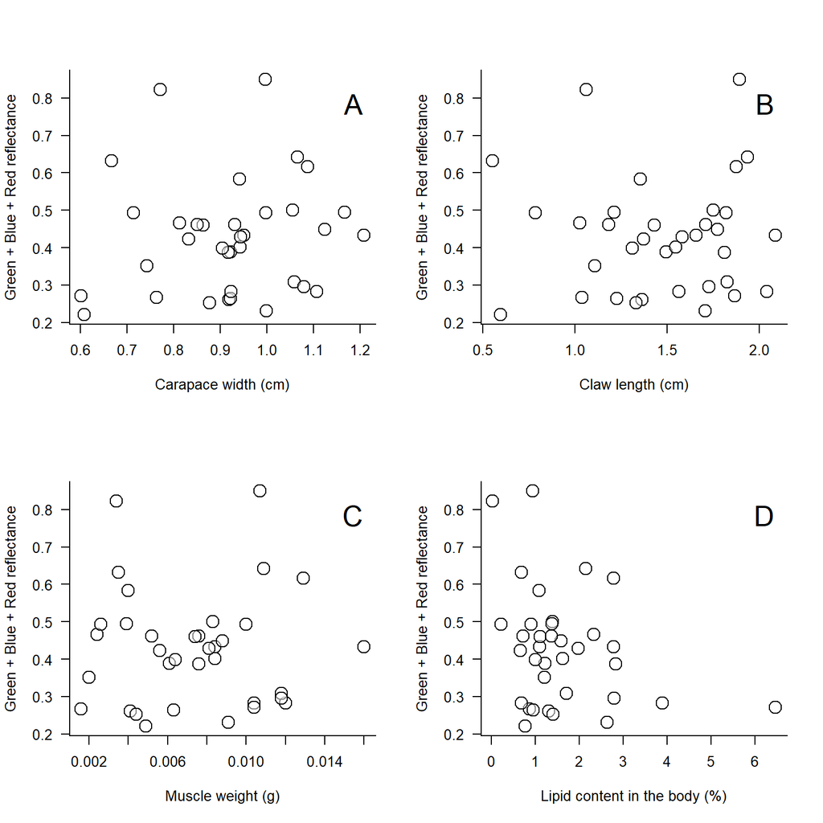

```r
par(mfrow = c(2,2))

plot(bright3 ~ carapace, data = color2.t, bty = 'l', las = 1, xlab = "Carapace width (cm)", ylab = "Green + Blue + Red reflectance",
     pch = 21, cex = 2, bg = alpha('white', 0.5))

legend("topright", legend = "A", cex = 2, bty = 'n')

plot(bright3 ~ claw, data = color2.t, bty = 'l', las = 1, xlab = "Claw length (cm)", ylab = "Green + Blue + Red reflectance",
     pch = 21, cex = 2, bg = alpha('white', 0.5))

legend("topright", legend = "B", cex = 2, bty = 'n')

plot(bright3 ~ muscle, data = color2.t, bty = 'l', las = 1, xlab = "Muscle weight (g)", ylab = "Green + Blue + Red reflectance",
     pch = 21, cex = 2, bg = alpha('white', 0.5))

legend("topright", legend = "C", cex = 2, bty = 'n')

plot(bright3 ~ lipid.percent, data = color2.t, xlab = "Lipid content in the body (%)", ylab = "Green + Blue + Red reflectance",
     pch = 21, cex = 2, bg = alpha('white', 0.5), bty = 'l', las = 1)

legend("topright", legend = "D", cex = 2, bty = 'n')
```

### Spearman correlation - Hue analysis

Now we are shifting to another aspect of color: hue. To get the hue for dichromatic vision, we divided raw blue by raw green reflectance and reran the correlation tests we did before. As before, the residuals were all over the place, so we opted to use a non-parametric tests

```r
#Calculating hue
color2.t$hue = color2.t$blue/color2.t$green

#Carapace length
car.hue1 = cor.test(x = color2.t$carapace, y = color2.t$hue, method = 'spearman')
car.hue1
```

```
##
##  Spearman's rank correlation rho
##
## data:  color2.t$carapace and color2.t$hue
## S = 8101.1, p-value = 0.4408
## alternative hypothesis: true rho is not equal to 0
## sample estimates:
##        rho
## -0.1346033
```

```r
#Claw length
claw.hue1 = cor.test(x = color2.t$claw, y = color2.t$hue, method = 'spearman')

claw.hue1
```

```
##
##  Spearman's rank correlation rho
##
## data:  color2.t$claw and color2.t$hue
## S = 8472, p-value = 0.2821
## alternative hypothesis: true rho is not equal to 0
## sample estimates:
##        rho
## -0.1865546
```

```r
#Muscle mass
musc.hue1 = cor.test(x = color2.t$muscle, y = color2.t$hue, method = 'spearman')
musc.hue1
```

```
##
##  Spearman's rank correlation rho
##
## data:  color2.t$muscle and color2.t$hue
## S = 8229.3, p-value = 0.3816
## alternative hypothesis: true rho is not equal to 0
## sample estimates:
##        rho
## -0.1525637
```

```r
#Lipid percentange
lipid.hue1 = cor.test(x = color2.t$lipid.percent, y = color2.t$hue, method = 'spearman')

lipid.hue1
```

```
##
##  Spearman's rank correlation rho
##
## data:  color2.t$lipid.percent and color2.t$hue
## S = 8180, p-value = 0.4023
## alternative hypothesis: true rho is not equal to 0
## sample estimates:
##        rho
## -0.1456583
```

#### Now, hue plots

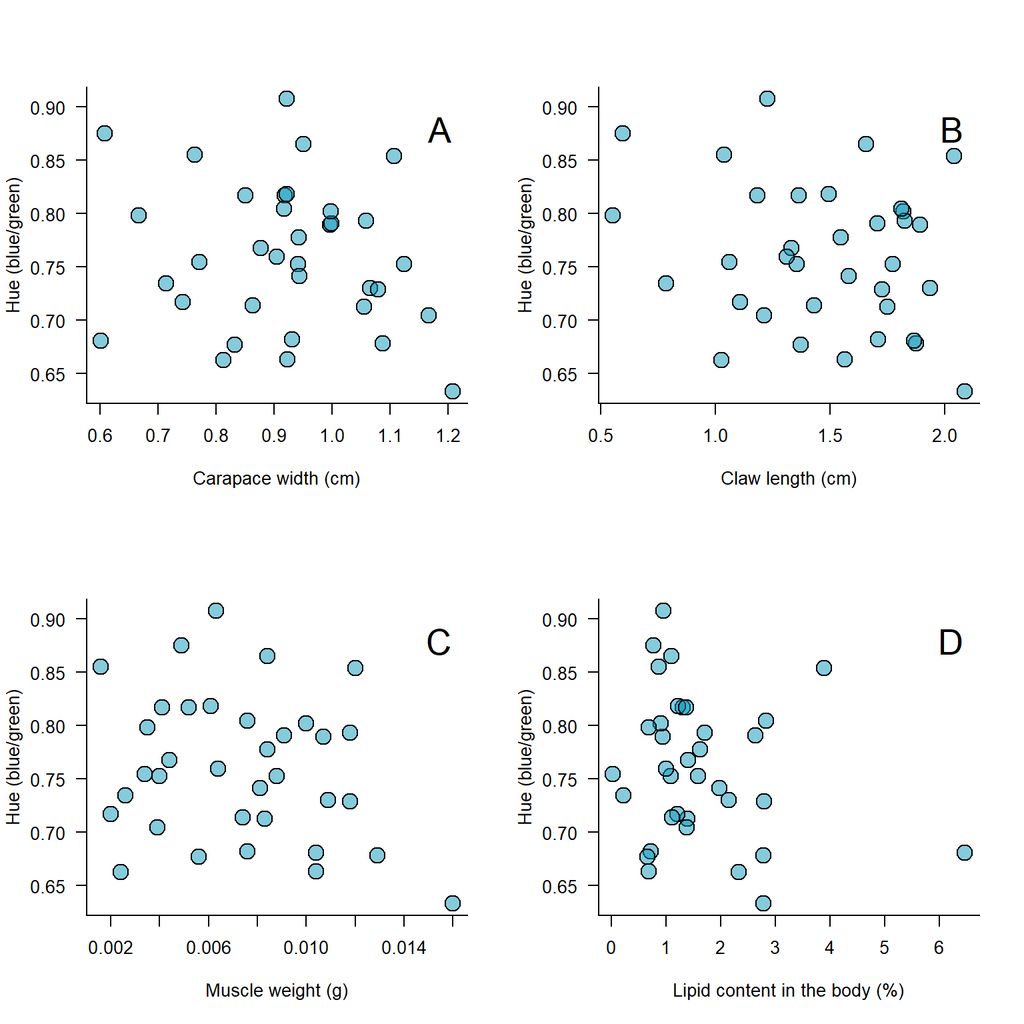

```r
par(mfrow=c(2,2))

{plot(hue ~ carapace, data = color2.t, bty = 'l', las = 1, xlab = "Carapace width (cm)", ylab = "Hue (blue/green)",
     pch = 21, cex = 2, bg = alpha('#0D98BA', 0.5))

legend("topright", legend = "A", cex = 2, bty = 'n')}

{plot(hue ~ claw, data = color2.t, bty = 'l', las = 1, xlab = "Claw length (cm)", ylab = "Hue (blue/green)",
     pch = 21, cex = 2, bg = alpha('#0D98BA', 0.5))

legend("topright", legend = "B", cex = 2, bty = 'n')}

{plot(hue ~ muscle, data = color2.t, bty = 'l', las = 1, xlab = "Muscle weight (g)", ylab = "Hue (blue/green)",
     pch = 21, cex = 2, bg = alpha('#0D98BA', 0.5))

legend("topright", legend = "C", cex = 2, bty = 'n')}

{plot(hue ~ lipid.percent, data = color2.t, xlab = "Lipid content in the body (%)", ylab = "Hue (blue/green)",
     pch = 21, cex = 2, bg = alpha('#0D98BA', 0.5), bty = 'l', las = 1)

legend("topright", legend = "D", cex = 2, bty = 'n')}
```

### Spearman correlation - Hue 2

We are using a secondary measure of hue because, while crabs are largely insensitive to red wavelengths, some manifestations of the red can be seen for the crabs. Instead of seeing red, they might see the claw as black, for instance. Thus, we opted to do a second measure of hue that includes red. To do this, we divided blue by the sum of green and red reflectance. We then ran ran the same analysis shown above.

```r
### Calculating hue 2

color2.t$hue2 = color2.t$blue/(color2.t$green+color2.t$red)

#Carapace length
car.hue2 = cor.test(x = color2.t$carapace, y = color2.t$hue2, method = 'spearman')
car.hue2
```

```
##
##  Spearman's rank correlation rho
##
## data:  color2.t$carapace and color2.t$hue2
## S = 8462.1, p-value = 0.2869
## alternative hypothesis: true rho is not equal to 0
## sample estimates:
##       rho
## -0.185167
```

```r
#Claw length
claw.hue2 = cor.test(x = color2.t$claw, y = color2.t$hue2, method = 'spearman')

claw.hue2
```

```
##
##  Spearman's rank correlation rho
##
## data:  color2.t$claw and color2.t$hue2
## S = 8688, p-value = 0.2101
## alternative hypothesis: true rho is not equal to 0
## sample estimates:
##        rho
## -0.2168067
```

```r
#Muscle mass
muscle.hue2 = cor.test(x = color2.t$muscle, y = color2.t$hue2, method = 'spearman')
muscle.hue2
```

```
##
##  Spearman's rank correlation rho
##
## data:  color2.t$muscle and color2.t$hue2
## S = 8394.4, p-value = 0.3128
## alternative hypothesis: true rho is not equal to 0
## sample estimates:
##        rho
## -0.1756795
```

```r
#Lipid percentage
lipid.hue2 = cor.test(x = color2.t$lipid.percent, y = color2.t$hue2, method = 'spearman')

lipid.hue2
```

```
##
##  Spearman's rank correlation rho
##
## data:  color2.t$lipid.percent and color2.t$hue2
## S = 9038, p-value = 0.1226
## alternative hypothesis: true rho is not equal to 0
## sample estimates:
##        rho
## -0.2658263
```

### Hue 2 plots

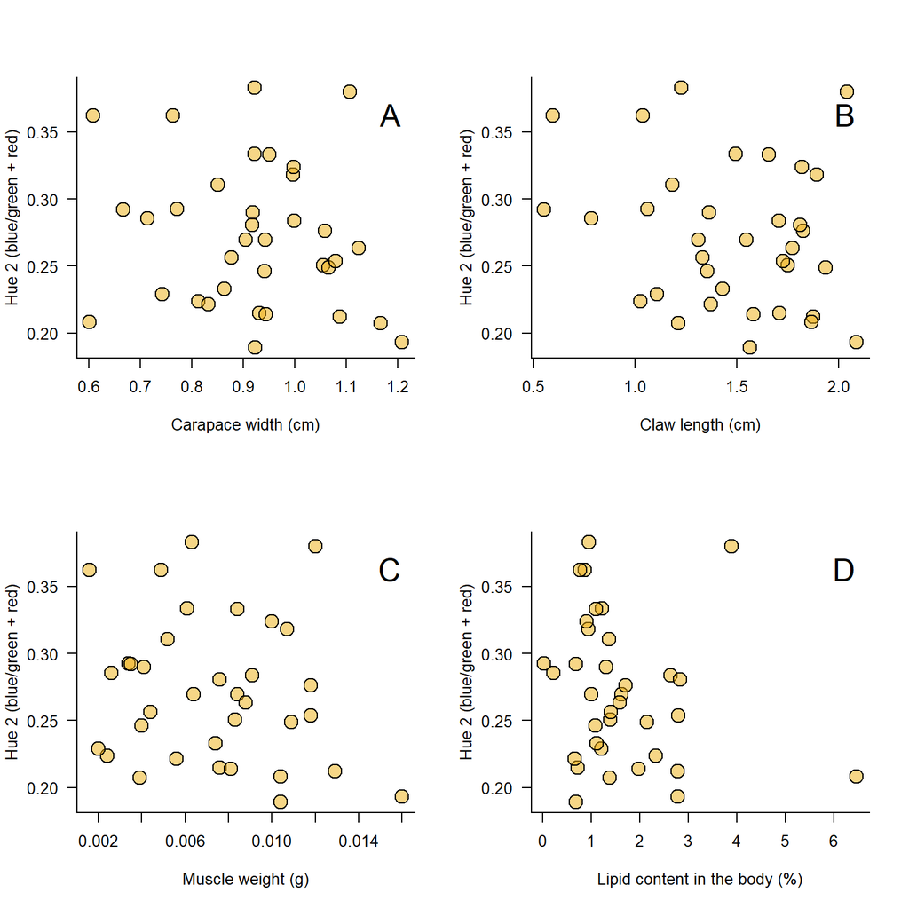

```r
par(mfrow=c(2,2))

{plot(hue2 ~ carapace, data = color2.t, bty = 'l', las = 1, xlab = "Carapace width (cm)", ylab = "Hue 2 (blue/green + red)",
     pch = 21, cex = 2, bg = alpha('darkgoldenrod2', 0.5))

legend("topright", legend = "A", cex = 2, bty = 'n')}

{plot(hue2 ~ claw, data = color2.t, bty = 'l', las = 1, xlab = "Claw length (cm)", ylab = "Hue 2 (blue/green + red)",
     pch = 21, cex = 2, bg = alpha('darkgoldenrod2', 0.5))

legend("topright", legend = "B", cex = 2, bty = 'n')}

{plot(hue2 ~ muscle, data = color2.t, bty = 'l', las = 1, xlab = "Muscle weight (g)", ylab = "Hue 2 (blue/green + red)",
     pch = 21, cex = 2, bg = alpha('darkgoldenrod2', 0.5))

legend("topright", legend = "C", cex = 2, bty = 'n')}

{plot(hue2 ~ lipid.percent, data = color2.t, xlab = "Lipid content in the body (%)", ylab = "Hue 2 (blue/green + red)",
     pch = 21, cex = 2, bg = alpha('darkgoldenrod2', 0.5), bty = 'l', las = 1)

legend("topright", legend = "D", cex = 2, bty = 'n')}
```

### Reflectance analysis - Beta regression - Red reflectance

```r
#Null model
r0 = betareg(red ~ 1, data = color2.t)

#Carapace length
r3 = betareg(red ~ carapace, data = color2.t)

summary(r3)
```

```
##
## Call:
## betareg(formula = red ~ carapace, data = color2.t)
##
## Standardized weighted residuals 2:
##     Min      1Q  Median      3Q     Max
## -1.8970 -0.7489  0.0406  0.6006  2.0861
##
## Coefficients (mean model with logit link):
##             Estimate Std. Error z value Pr(>|z|)
## (Intercept)  -1.7740     0.4745  -3.739 0.000185 ***
## carapace      0.5433     0.5047   1.076 0.281748
##
## Phi coefficients (precision model with identity link):
##       Estimate Std. Error z value Pr(>|z|)
## (phi)   28.528      6.746   4.229 2.35e-05 ***
## ---
## Signif. codes:  0 '***' 0.001 '**' 0.01 '*' 0.05 '.' 0.1 ' ' 1
##
## Type of estimator: ML (maximum likelihood)
## Log-likelihood: 41.37 on 3 Df
## Pseudo R-squared: 0.03355
## Number of iterations: 22 (BFGS) + 3 (Fisher scoring)
```

```r
parameters::standardise_parameters(r3)
```

```
## # Standardization method: refit
##
## Parameter   | Std. Coef. |         95% CI
## -----------------------------------------
## (Intercept) |      -1.27 | [-1.42, -1.13]
## carapace    |       0.08 | [-0.07,  0.23]
##
## - Response is unstandardized.
```

```r
#likelihood ratio test
lrtest(r0,r3)
```

```
## Likelihood ratio test
##
## Model 1: red ~ 1
## Model 2: red ~ carapace
##   #Df LogLik Df  Chisq Pr(>Chisq)
## 1   2 40.788
## 2   3 41.368  1 1.1603     0.2814
```

```r
#Claw length
r1 = betareg(red ~ claw, data = color2.t)

summary(r1)
```

```
##
## Call:
## betareg(formula = red ~ claw, data = color2.t)
##
## Standardized weighted residuals 2:
##     Min      1Q  Median      3Q     Max
## -1.8659 -0.8520  0.0907  0.5600  1.9954
##
## Coefficients (mean model with logit link):
##             Estimate Std. Error z value Pr(>|z|)
## (Intercept) -1.41720    0.29805  -4.755 1.99e-06 ***
## claw         0.09853    0.19427   0.507    0.612
##
## Phi coefficients (precision model with identity link):
##       Estimate Std. Error z value Pr(>|z|)
## (phi)    27.79       6.57    4.23 2.34e-05 ***
## ---
## Signif. codes:  0 '***' 0.001 '**' 0.01 '*' 0.05 '.' 0.1 ' ' 1
##
## Type of estimator: ML (maximum likelihood)
## Log-likelihood: 40.92 on 3 Df
## Pseudo R-squared: 0.00732
## Number of iterations: 15 (BFGS) + 3 (Fisher scoring)
```

```r
parameters::standardise_parameters(r1)
```

```
## # Standardization method: refit
##
## Parameter   | Std. Coef. |         95% CI
## -----------------------------------------
## (Intercept) |      -1.27 | [-1.42, -1.12]
## claw        |       0.04 | [-0.11,  0.19]
##
## - Response is unstandardized.
```

```r
#likelihood ratio test
lrtest(r0,r1)
```

```
## Likelihood ratio test
##
## Model 1: red ~ 1
## Model 2: red ~ claw
##   #Df LogLik Df  Chisq Pr(>Chisq)
## 1   2 40.788
## 2   3 40.916  1 0.2551     0.6135
```

```r
#Muscle mass
r2 = betareg(red ~ muscle, data = color2.t)

summary(r2)
```

```
##
## Call:
## betareg(formula = red ~ muscle, data = color2.t)
##
## Standardized weighted residuals 2:
##     Min      1Q  Median      3Q     Max
## -1.9354 -0.8212  0.1307  0.6008  1.9666
##
## Coefficients (mean model with logit link):
##             Estimate Std. Error z value Pr(>|z|)
## (Intercept)  -1.3169     0.1763  -7.470 8.03e-14 ***
## muscle        6.1769    21.5240   0.287    0.774
##
## Phi coefficients (precision model with identity link):
##       Estimate Std. Error z value Pr(>|z|)
## (phi)   27.651      6.537    4.23 2.34e-05 ***
## ---
## Signif. codes:  0 '***' 0.001 '**' 0.01 '*' 0.05 '.' 0.1 ' ' 1
##
## Type of estimator: ML (maximum likelihood)
## Log-likelihood: 40.83 on 3 Df
## Pseudo R-squared: 0.002269
## Number of iterations: 127 (BFGS) + 5 (Fisher scoring)
```

```r
parameters::standardise_parameters(r2)
```

```
## # Standardization method: refit
##
## Parameter   | Std. Coef. |         95% CI
## -----------------------------------------
## (Intercept) |      -1.27 | [-1.42, -1.12]
## muscle      |       0.02 | [-0.13,  0.17]
##
## - Response is unstandardized.
```

```r
#likelihood ratio test
lrtest(r0,r2)
```

```
## Likelihood ratio test
##
## Model 1: red ~ 1
## Model 2: red ~ muscle
##   #Df LogLik Df  Chisq Pr(>Chisq)
## 1   2 40.788
## 2   3 40.828  1 0.0802      0.777
```

```r
#Lipid percentage
r4 = lm(red ~ lipid.percent, data = color2.t)

summary(r4)
```

```
##
## Call:
## lm(formula = red ~ lipid.percent, data = color2.t)
##
## Residuals:
##       Min        1Q    Median        3Q       Max
## -0.136467 -0.056216 -0.004506  0.040960  0.156268
##
## Coefficients:
##               Estimate Std. Error t value Pr(>|t|)
## (Intercept)    0.24232    0.02239  10.822 2.16e-12 ***
## lipid.percent -0.01450    0.01121  -1.293    0.205
## ---
## Signif. codes:  0 '***' 0.001 '**' 0.01 '*' 0.05 '.' 0.1 ' ' 1
##
## Residual standard error: 0.07837 on 33 degrees of freedom
## Multiple R-squared:  0.0482, Adjusted R-squared:  0.01936
## F-statistic: 1.671 on 1 and 33 DF,  p-value: 0.2051
```

```r
parameters::standardise_parameters(r4)
```

```
## # Standardization method: refit
##
## Parameter     | Std. Coef. |        95% CI
## ------------------------------------------
## (Intercept)   |   1.82e-16 | [-0.34, 0.34]
## lipid.percent |      -0.22 | [-0.57, 0.13]
```

```r
#likelihood ratio test
lrtest(r0,r4)
```

```
## Likelihood ratio test
##
## Model 1: red ~ 1
## Model 2: red ~ lipid.percent
##   #Df LogLik Df  Chisq Pr(>Chisq)
## 1   2 40.788
## 2   3 40.489  1 0.5978     0.4394
```

### Red reflectance plots

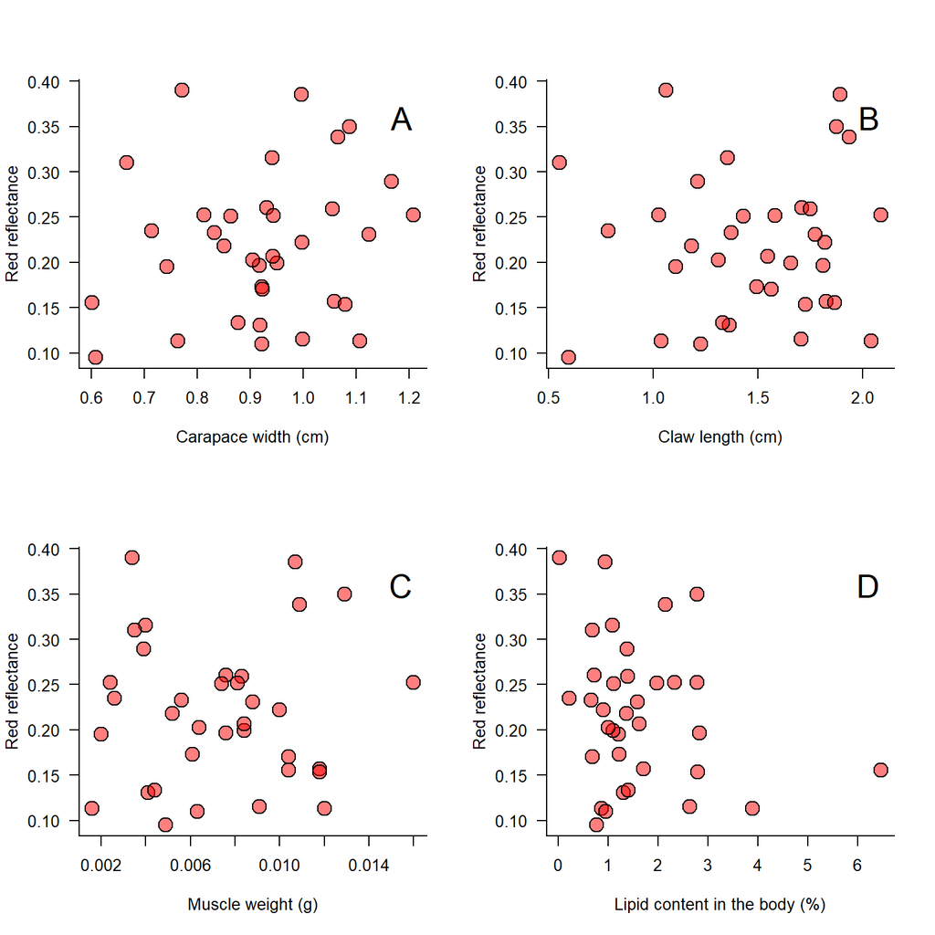

```r
par(mfrow = c(2,2))

{plot(red ~ carapace, data = color2.t, bty = 'l', las = 1, xlab = "Carapace width (cm)", ylab = "Red reflectance",
     pch = 21, cex = 2, bg = alpha('red', 0.5))

legend("topright", legend = "A", cex = 2, bty = 'n')}

{plot(red ~ claw, data = color2.t, bty = 'l', las = 1, xlab = "Claw length (cm)", ylab = "Red reflectance",
     pch = 21, cex = 2, bg = alpha('red', 0.5))

legend("topright", legend = "B", cex = 2, bty = 'n')}

{plot(red ~ muscle, data = color2.t, bty = 'l', las = 1, xlab = "Muscle weight (g)", ylab = "Red reflectance",
     pch = 21, cex = 2, bg = alpha('red', 0.5))

legend("topright", legend = "C", cex = 2, bty = 'n')}

{plot(red ~ lipid.percent, data = color2.t, xlab = "Lipid content in the body (%)", ylab = "Red reflectance",
     pch = 21, cex = 2, bg = alpha('red', 0.5), bty = 'l', las = 1)

legend("topright", legend = "D", cex = 2, bty = 'n')}
```

### Beta regression models - Blue reflectance

Same thing we did for the red reflectance, but now with the blue reflectance.

```r
#Null model
b0 = betareg(blue ~ 1, data = color2.t)

#Carapace length
b3 = betareg(blue ~ carapace, data = color2.t)

summary(b3)
```

```
##
## Call:
## betareg(formula = blue ~ carapace, data = color2.t)
##
## Standardized weighted residuals 2:
##     Min      1Q  Median      3Q     Max
## -1.7128 -0.6762 -0.0168  0.6202  2.5425
##
## Coefficients (mean model with logit link):
##             Estimate Std. Error z value Pr(>|z|)
## (Intercept)  -2.4551     0.4078  -6.021 1.74e-09 ***
## carapace      0.1608     0.4352   0.369    0.712
##
## Phi coefficients (precision model with identity link):
##       Estimate Std. Error z value Pr(>|z|)
## (phi)    79.19      18.99    4.17 3.05e-05 ***
## ---
## Signif. codes:  0 '***' 0.001 '**' 0.01 '*' 0.05 '.' 0.1 ' ' 1
##
## Type of estimator: ML (maximum likelihood)
## Log-likelihood: 72.02 on 3 Df
## Pseudo R-squared: 0.004724
## Number of iterations: 22 (BFGS) + 2 (Fisher scoring)
```

```r
parameters::standardise_parameters(b3)
```

```
## # Standardization method: refit
##
## Parameter   | Std. Coef. |         95% CI
## -----------------------------------------
## (Intercept) |      -2.31 | [-2.44, -2.18]
## carapace    |       0.02 | [-0.10,  0.15]
##
## - Response is unstandardized.
```

```r
#likelihood ratio test
lrtest(b0,b3)
```

```
## Likelihood ratio test
##
## Model 1: blue ~ 1
## Model 2: blue ~ carapace
##   #Df LogLik Df  Chisq Pr(>Chisq)
## 1   2 71.946
## 2   3 72.018  1 0.1437     0.7046
```

```r
#Claw length
b1 = betareg(blue ~ claw, data = color2.t)

summary(b1)
```

```
##
## Call:
## betareg(formula = blue ~ claw, data = color2.t)
##
## Standardized weighted residuals 2:
##     Min      1Q  Median      3Q     Max
## -1.6938 -0.6074 -0.0569  0.6312  2.6374
##
## Coefficients (mean model with logit link):
##             Estimate Std. Error z value Pr(>|z|)
## (Intercept)  -2.2124     0.2500  -8.849   <2e-16 ***
## claw         -0.0641     0.1644  -0.390    0.697
##
## Phi coefficients (precision model with identity link):
##       Estimate Std. Error z value Pr(>|z|)
## (phi)    79.19      18.99    4.17 3.05e-05 ***
## ---
## Signif. codes:  0 '***' 0.001 '**' 0.01 '*' 0.05 '.' 0.1 ' ' 1
##
## Type of estimator: ML (maximum likelihood)
## Log-likelihood: 72.02 on 3 Df
## Pseudo R-squared: 0.004158
## Number of iterations: 36 (BFGS) + 3 (Fisher scoring)
```

```r
parameters::standardise_parameters(b1)
```

```
## # Standardization method: refit
##
## Parameter   | Std. Coef. |         95% CI
## -----------------------------------------
## (Intercept) |      -2.31 | [-2.44, -2.18]
## claw        |      -0.03 | [-0.15,  0.10]
##
## - Response is unstandardized.
```

```r
#likelihood ratio test
lrtest(b0,b1)
```

```
## Likelihood ratio test
##
## Model 1: blue ~ 1
## Model 2: blue ~ claw
##   #Df LogLik Df Chisq Pr(>Chisq)
## 1   2 71.946
## 2   3 72.017  1 0.142     0.7063
```

```r
#Muscle mass
b2 = betareg(blue ~ muscle, data = color2.t)

summary(b2)
```

```
##
## Call:
## betareg(formula = blue ~ muscle, data = color2.t)
##
## Standardized weighted residuals 2:
##     Min      1Q  Median      3Q     Max
## -1.6370 -0.6312 -0.0997  0.6236  2.6404
##
## Coefficients (mean model with logit link):
##             Estimate Std. Error z value Pr(>|z|)
## (Intercept)   -2.239      0.149 -15.024   <2e-16 ***
## muscle        -9.324     18.445  -0.506    0.613
##
## Phi coefficients (precision model with identity link):
##       Estimate Std. Error z value Pr(>|z|)
## (phi)    79.46      19.06    4.17 3.05e-05 ***
## ---
## Signif. codes:  0 '***' 0.001 '**' 0.01 '*' 0.05 '.' 0.1 ' ' 1
##
## Type of estimator: ML (maximum likelihood)
## Log-likelihood: 72.08 on 3 Df
## Pseudo R-squared: 0.008141
## Number of iterations: 22 (BFGS) + 4 (Fisher scoring)
```

```r
parameters::standardise_parameters(b2)
```

```
## # Standardization method: refit
##
## Parameter   | Std. Coef. |         95% CI
## -----------------------------------------
## (Intercept) |      -2.31 | [-2.44, -2.18]
## muscle      |      -0.03 | [-0.16,  0.09]
##
## - Response is unstandardized.
```

```r
#likelihood ratio test
lrtest(b0,b2)
```

```
## Likelihood ratio test
##
## Model 1: blue ~ 1
## Model 2: blue ~ muscle
##   #Df LogLik Df  Chisq Pr(>Chisq)
## 1   2 71.946
## 2   3 72.075  1 0.2583     0.6113
```

```r
#Lipid content
b4 = betareg(blue ~ lipid.percent, data = color2.t)

summary(b4)
```

```
##
## Call:
## betareg(formula = blue ~ lipid.percent, data = color2.t)
##
## Standardized weighted residuals 2:
##     Min      1Q  Median      3Q     Max
## -2.2983 -0.6928 -0.0002  0.5144  2.6040
##
## Coefficients (mean model with logit link):
##               Estimate Std. Error z value Pr(>|z|)
## (Intercept)   -2.11671    0.10472 -20.214   <2e-16 ***
## lipid.percent -0.12297    0.05711  -2.153   0.0313 *
##
## Phi coefficients (precision model with identity link):
##       Estimate Std. Error z value Pr(>|z|)
## (phi)    90.85      21.78   4.171 3.03e-05 ***
## ---
## Signif. codes:  0 '***' 0.001 '**' 0.01 '*' 0.05 '.' 0.1 ' ' 1
##
## Type of estimator: ML (maximum likelihood)
## Log-likelihood: 74.38 on 3 Df
## Pseudo R-squared: 0.1492
## Number of iterations: 196 (BFGS) + 3 (Fisher scoring)
```

```r
parameters::standardise_parameters(b4)
```

```
## # Standardization method: refit
##
## Parameter     | Std. Coef. |         95% CI
## -------------------------------------------
## (Intercept)   |      -2.31 | [-2.44, -2.19]
## lipid.percent |      -0.15 | [-0.28, -0.01]
##
## - Response is unstandardized.
```

```r
#likelihood ratio test
lrtest(b0,b4)
```

```
## Likelihood ratio test
##
## Model 1: blue ~ 1
## Model 2: blue ~ lipid.percent
##   #Df LogLik Df  Chisq Pr(>Chisq)
## 1   2 71.946
## 2   3 74.376  1 4.8594     0.0275 *
## ---
## Signif. codes:  0 '***' 0.001 '**' 0.01 '*' 0.05 '.' 0.1 ' ' 1
```

### Blue reflectance plots

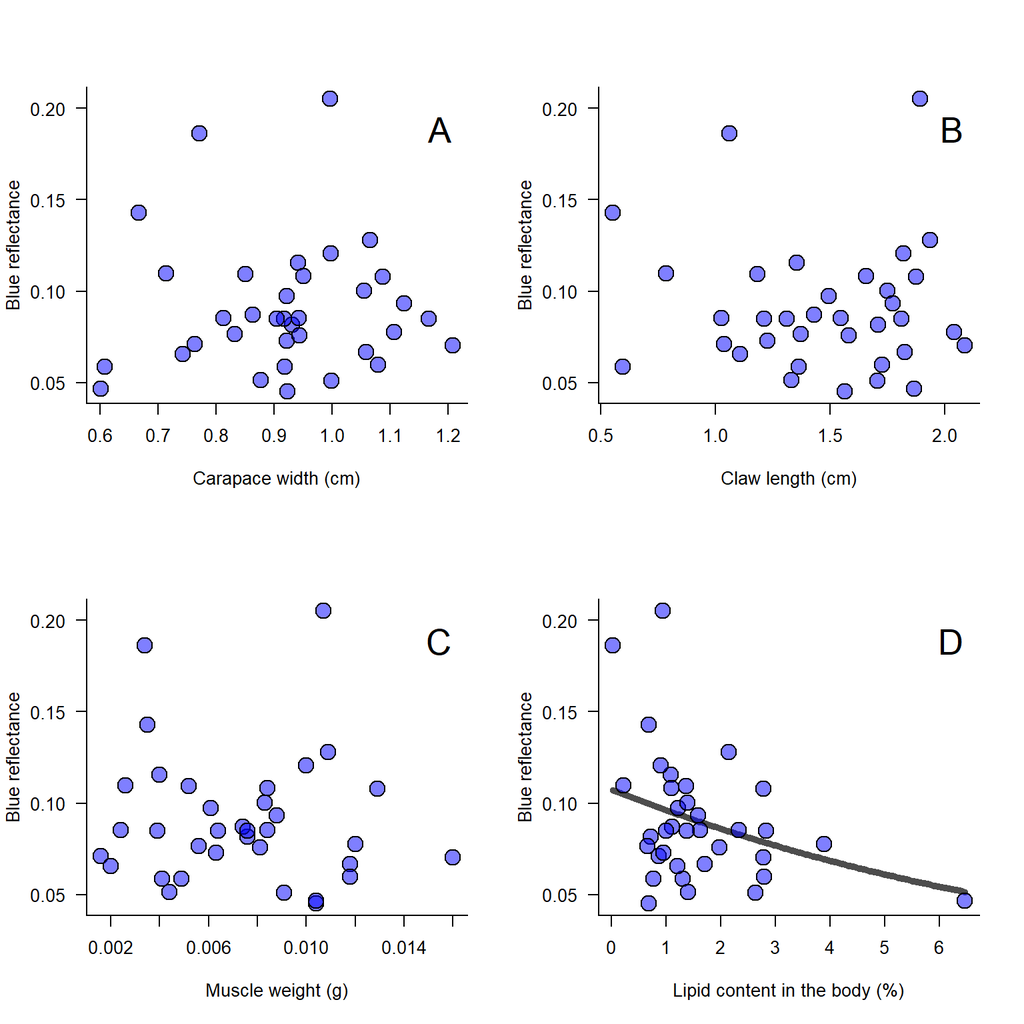

```r
par(mfrow = c(2,2))

{plot(blue ~ carapace, data = color2.t, bty = 'l', las = 1, xlab = "Carapace width (cm)", ylab = "Blue reflectance",
     pch = 21, cex = 2, bg = alpha('blue', 0.5))
legend("topright", legend = "A", cex = 2, bty = 'n')}

{plot(blue ~ claw, data = color2.t, bty = 'l', las = 1, xlab = "Claw length (cm)", ylab = "Blue reflectance",
     pch = 21, cex = 2, bg = alpha('blue', 0.5))

legend("topright", legend = "B", cex = 2, bty = 'n')}


{plot(blue ~ muscle, data = color2.t, bty = 'l', las = 1,
     xlab = "Muscle weight (g)", ylab = "Blue reflectance",
     pch = 21, cex = 2, bg = alpha('blue', 0.5))

legend("topright", legend = "C", cex = 2, bty = 'n')}

rn <- range(color2.t$lipid.percent)
newdata <- data.frame(lipid.percent = seq(rn[1], rn[2], length.out = 100))

plotData <- xy.coords(x = newdata$lipid.percent, y = predict(b4, newdata = newdata, type = 'response'))

{plot(plotData, ylim = range(color2.t$blue), type = 'l', las = 1, bty = 'l',
     ylab = "Blue reflectance", xlab = "Lipid content in the body (%)",
     lwd = 5, col = 'grey30')

points(x = color2.t$lipid.percent, y = color2.t$blue, cex = 2, pch = 21,
       bg = alpha('blue',0.5))

legend("topright", legend = "D", cex = 2, bty = 'n')}
```

### Beta regression models - Green reflectance

```r
#Null model
g0 = betareg(green ~ 1, data = color2.t)

#Carapace width
g3 = betareg(green ~ carapace, data = color2.t)

summary(g3)
```

```
##
## Call:
## betareg(formula = green ~ carapace, data = color2.t)
##
## Standardized weighted residuals 2:
##     Min      1Q  Median      3Q     Max
## -1.5642 -0.8320  0.0163  0.5266  2.4513
##
## Coefficients (mean model with logit link):
##             Estimate Std. Error z value Pr(>|z|)
## (Intercept)  -2.2385     0.4207  -5.321 1.03e-07 ***
## carapace      0.2619     0.4484   0.584    0.559
##
## Phi coefficients (precision model with identity link):
##       Estimate Std. Error z value Pr(>|z|)
## (phi)    58.56      14.00   4.182 2.89e-05 ***
## ---
## Signif. codes:  0 '***' 0.001 '**' 0.01 '*' 0.05 '.' 0.1 ' ' 1
##
## Type of estimator: ML (maximum likelihood)
## Log-likelihood: 62.43 on 3 Df
## Pseudo R-squared: 0.01119
## Number of iterations: 28 (BFGS) + 2 (Fisher scoring)
```

```r
parameters::standardise_parameters(g3)
```

```
## # Standardization method: refit
##
## Parameter   | Std. Coef. |         95% CI
## -----------------------------------------
## (Intercept) |      -2.00 | [-2.13, -1.86]
## carapace    |       0.04 | [-0.09,  0.17]
##
## - Response is unstandardized.
```

```r
#likelihood ratio test
lrtest(g0,g3)
```

```
## Likelihood ratio test
##
## Model 1: green ~ 1
## Model 2: green ~ carapace
##   #Df LogLik Df  Chisq Pr(>Chisq)
## 1   2 62.251
## 2   3 62.427  1 0.3517     0.5531
```

```r
#Claw length
g1 = betareg(green ~ claw, data = color2.t)

summary(g1)
```

```
##
## Call:
## betareg(formula = green ~ claw, data = color2.t)
##
## Standardized weighted residuals 2:
##     Min      1Q  Median      3Q     Max
## -1.5409 -0.8284  0.0021  0.5433  2.5107
##
## Coefficients (mean model with logit link):
##              Estimate Std. Error z value Pr(>|z|)
## (Intercept) -1.981908   0.260571  -7.606 2.83e-14 ***
## claw        -0.009886   0.170660  -0.058    0.954
##
## Phi coefficients (precision model with identity link):
##       Estimate Std. Error z value Pr(>|z|)
## (phi)    57.98      13.86   4.182 2.89e-05 ***
## ---
## Signif. codes:  0 '***' 0.001 '**' 0.01 '*' 0.05 '.' 0.1 ' ' 1
##
## Type of estimator: ML (maximum likelihood)
## Log-likelihood: 62.25 on 3 Df
## Pseudo R-squared: 9.327e-05
## Number of iterations: 22 (BFGS) + 3 (Fisher scoring)
```

```r
parameters::standardise_parameters(g1)
```

```
## # Standardization method: refit
##
## Parameter   | Std. Coef. |         95% CI
## -----------------------------------------
## (Intercept) |      -2.00 | [-2.13, -1.86]
## claw        |  -3.89e-03 | [-0.14,  0.13]
##
## - Response is unstandardized.
```

```r
#likelihood ratio test
lrtest(g0,g1)
```

```
## Likelihood ratio test
##
## Model 1: green ~ 1
## Model 2: green ~ claw
##   #Df LogLik Df  Chisq Pr(>Chisq)
## 1   2 62.251
## 2   3 62.253  1 0.0032      0.955
```

```r
#Muscle mass
g2 = betareg(green ~ muscle, data = color2.t)

summary(g2)
```

```
##
## Call:
## betareg(formula = green ~ muscle, data = color2.t)
##
## Standardized weighted residuals 2:
##     Min      1Q  Median      3Q     Max
## -1.4693 -0.7990  0.0401  0.5355  2.5177
##
## Coefficients (mean model with logit link):
##             Estimate Std. Error z value Pr(>|z|)
## (Intercept)  -1.9680     0.1548 -12.716   <2e-16 ***
## muscle       -3.8934    19.0381  -0.205    0.838
##
## Phi coefficients (precision model with identity link):
##       Estimate Std. Error z value Pr(>|z|)
## (phi)    58.04      13.88   4.182 2.89e-05 ***
## ---
## Signif. codes:  0 '***' 0.001 '**' 0.01 '*' 0.05 '.' 0.1 ' ' 1
##
## Type of estimator: ML (maximum likelihood)
## Log-likelihood: 62.27 on 3 Df
## Pseudo R-squared: 0.001257
## Number of iterations: 29 (BFGS) + 4 (Fisher scoring)
```

```r
parameters::standardise_parameters(g2)
```

```
## # Standardization method: refit
##
## Parameter   | Std. Coef. |         95% CI
## -----------------------------------------
## (Intercept) |      -2.00 | [-2.13, -1.86]
## muscle      |      -0.01 | [-0.15,  0.12]
##
## - Response is unstandardized.
```

```r
#likelihood ratio test
lrtest(g0,g2)
```

```
## Likelihood ratio test
##
## Model 1: green ~ 1
## Model 2: green ~ muscle
##   #Df LogLik Df  Chisq Pr(>Chisq)
## 1   2 62.251
## 2   3 62.272  1 0.0412     0.8391
```

```r
#Lipid percentage
g4 = lm(green ~ lipid.percent, data = color2.t)

summary(g4)
```

```
##
## Call:
## lm(formula = green ~ lipid.percent, data = color2.t)
##
## Residuals:
##       Min        1Q    Median        3Q       Max
## -0.063291 -0.027783 -0.001747  0.015233  0.132066
##
## Coefficients:
##               Estimate Std. Error t value Pr(>|t|)
## (Intercept)    0.13973    0.01260  11.091 1.14e-12 ***
## lipid.percent -0.01264    0.00631  -2.003   0.0534 .
## ---
## Signif. codes:  0 '***' 0.001 '**' 0.01 '*' 0.05 '.' 0.1 ' ' 1
##
## Residual standard error: 0.04409 on 33 degrees of freedom
## Multiple R-squared:  0.1084, Adjusted R-squared:  0.08141
## F-statistic: 4.013 on 1 and 33 DF,  p-value: 0.05341
```

```r
parameters::standardise_parameters(g4)
```

```
## # Standardization method: refit
##
## Parameter     | Std. Coef. |        95% CI
## ------------------------------------------
## (Intercept)   |   7.19e-17 | [-0.33, 0.33]
## lipid.percent |      -0.33 | [-0.66, 0.01]
```

```r
#likelihood ratio test
lrtest(g0,g4)
```

```
## Likelihood ratio test
##
## Model 1: green ~ 1
## Model 2: green ~ lipid.percent
##   #Df LogLik Df  Chisq Pr(>Chisq)
## 1   2 62.251
## 2   3 60.619  1 3.2638    0.07083 .
## ---
## Signif. codes:  0 '***' 0.001 '**' 0.01 '*' 0.05 '.' 0.1 ' ' 1
```

### Green reflectance plots

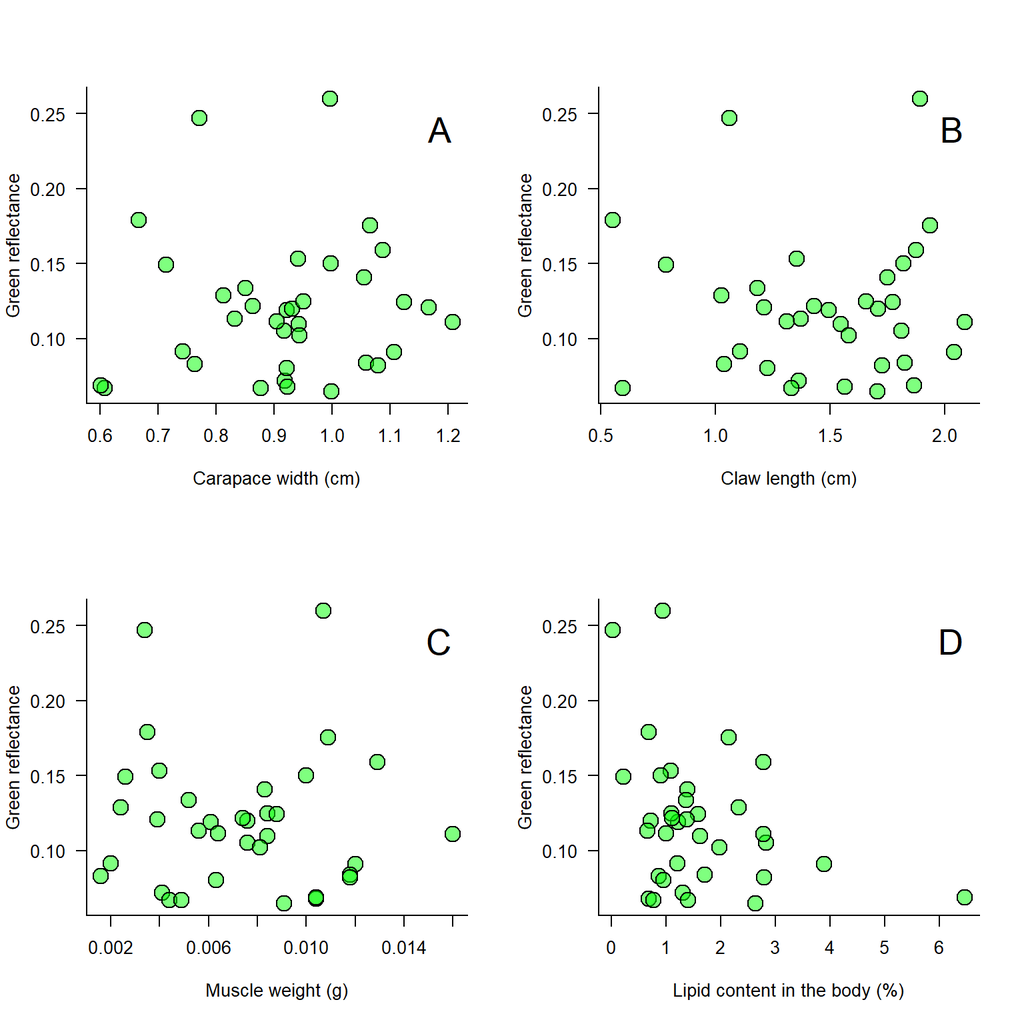

```r
par(mfrow = c(2,2))

{plot(green ~ carapace, data = color2.t, bty = 'l', las = 1, xlab = "Carapace width (cm)", ylab = "Green reflectance",
     pch = 21, cex = 2, bg = alpha('green', 0.5))

legend("topright", legend = "A", cex = 2, bty = 'n')}

{plot(green ~ claw, data = color2.t, bty = 'l', las = 1, xlab = "Claw length (cm)", ylab = "Green reflectance",
     pch = 21, cex = 2, bg = alpha('green', 0.5))

legend("topright", legend = "B", cex = 2, bty = 'n')}

{plot(green ~ muscle, data = color2.t, bty = 'l', las = 1, xlab = "Muscle weight (g)", ylab = "Green reflectance",
     pch = 21, cex = 2, bg = alpha('green', 0.5))

legend("topright", legend = "C", cex = 2, bty = 'n')}

{plot(green ~ lipid.percent, data = color2.t, xlab = "Lipid content in the body (%)", ylab = "Green reflectance",
     pch = 21, cex = 2, bg = alpha('green', 0.5), bty = 'l', las = 1)

legend("topright", legend = "D", cex = 2, bty = 'n')}
```